# SST MHW Simulations - CBWMWT

August 2023

This analysis is focused on modeling effects of trends in SST mean and variance following Oliver 2019. The site is at the location of the NOAA tide/met station at Wachapreague, VA. The record extends from 1982-2021 (40 years).

This block reads in data.

```r
library(lubridate)
XDdf=read.csv("SST_COC_CBW_Aug2023.csv") #meas WT avgd over LST
Xdf=data.frame(XDdf$CBWMWT) #CBWMeas WTDA
dt=mdy(XDdf$dt)
dd=decimal_date(dt)
Ddf=data.frame(dt,dd,year(dt),month(dt),day(dt))
colnames(Ddf)=c("Date","DecY","Y","M","D")
```

Check lengths

```r
LD=length(Ddf$Y)
ild=which(Ddf$M==2&Ddf$D==29)
if (length(ild)>0) Ddf=Ddf[-ild,]
YV=unique(Ddf$Y)
NY=length(YV)

NR=length(Ddf$Y)
LX=dim(Xdf)[1]
print(c(NY,NR,LX,LD))
```

```
## [1]    40 14600 14610 14610
```

```r
if(LX==LD & length(ild>0)) Xdf=Xdf[-ild,]
if(LX!=LD & LX!=NR) print (c("input dataframes not same length"))
```

Run marine heatwave code heatwaveR

```r
library(heatwaveR)
Hdf=data.frame(Ddf$Date,Xdf)
colnames(Hdf)=c("t","temp")
YHdf=Hdf; YHdf$Y=Ddf$Y; YHdf$DecY=Ddf$DecY
Xclim=ts2clm(Hdf,climatologyPeriod = c("1987-01-01", "2016-12-31"), clmOnly=TRUE)
Xthresh=Xclim$thresh[-60]  #ignore leapday; MHW threshold
XthV=rep(Xthresh,NY)
Xseas=Xclim$seas[-60]  #ignore leapday; climatology
XsV=rep(Xseas,NY)
YHdf$tmseas=Hdf$temp-XsV
SSTAnom=YHdf$tmseas  #SST anomaly
```

Calculate statistics for time series (mean and variance)

```r
#calculate annual mean SST
Xmean=aggregate(YHdf$temp ~ YHdf$Y, FUN=mean, na.action=na.pass)
colnames(Xmean)=c("Y","Tmean")
XMM=t.test(Xmean$Tmean, na.rm=TRUE)  #confint on mean SST
fitmS=lm(YHdf$tmseas ~ YHdf$DecY)  #trend on daily SST anomaly
trend=fitmS$coefficients[1]+fitmS$coefficients[2]*YHdf$DecY
YHdf$tdT=YHdf$tmseas-trend #detrend SST time series
#calculate annual variance
Xvar=aggregate(YHdf$tdT ~ YHdf$Y, FUN=var, na.action=na.pass)
colnames(Xvar)=c("Y","Tvar")
XVM=t.test(Xvar$Tvar, na.rm=TRUE)  #confint on mean variance
fitam=lm(Xmean$Tmean~Xmean$Y) #trend on annual mean SST
print(paste("ann mean SST =", format(XMM$estimate,digits=3),"+/-",format(XMM$conf.int[2]-XMM$estimate,digits=1)))
```

```
## [1] "ann mean SST = 16.5 +/- 0.2"
```

```r
print(paste("ann mean SST trend =",format(fitam$coefficients[2],  digits=3),"+/-",format(confint(fitam)[2,2]-fitam$coefficients[2], digits=3)))
```

```
## [1] "ann mean SST trend = 0.0219 +/- 0.0149"
```

```r
print(paste("p = ", format(summary(fitam)$coefficients[2,4],digits=3)))
```

```
## [1] "p =  0.00516"
```

```r
fitav=lm(Xvar$Tvar~Xvar$Y)  #trend on annual variance
print(paste("ann SST var =", format(XVM$estimate,digits=3),"+/-",format(XVM$conf.int[2]-XVM$estimate,digits=2)))
```

```
## [1] "ann SST var = 5.93 +/- 0.42"
```

```r
print(paste("ann SST var trend =",format(fitav$coefficients[2],  digits=3),"+/-",format(confint(fitav)[2,2]-fitav$coefficients[2], digits=3)))
```

```
## [1] "ann SST var trend = 0.0122 +/- 0.0382"
```

```r
print(paste("p = ", format(summary(fitav)$coefficients[2,4],digits=3)))
```

```
## [1] "p =  0.519"
```

Calculate MHW stats

```r
Xhi=rep(0,NR); N28=Xhi
Xhi[(Hdf$temp-XthV)>0]=1
N28[Hdf$temp>=28]=1
a28=aggregate(N28 ~ Ddf$Y, FUN=sum, na.action=na.pass)
colnames(a28)=c("Y","abv28")
Xa28=rep(0,length(YV))
Xa28[a28$Y-YV[1]+1]=a28$abv28
frachi=sum(Xhi)/NR
dX=diff(Xhi)
nd = which(dX==1)
np = which(dX==-1)
if (np[1]<nd[1]) np=np[-1]
if (length(np) != length(nd)) nd=nd[-length(nd)]
durXHi=np-nd
n5=which(durXHi>=5)

Dexp=aggregate(durXHi[n5] ~ Ddf$Y[nd[n5]], FUN=sum, na.action=na.pass)
Ddur=aggregate(durXHi[n5] ~ Ddf$Y[nd[n5]], FUN=mean, na.action=na.pass)
colnames(Dexp)=c("Y","expMHW")
colnames(Ddur)=c("Y","durMHW")
Xexp=rep(0,length(YV))
Xexp[Dexp$Y-YV[1]+1]=Dexp$expMHW
Xdur=rep(0,length(YV))
Xdur[Ddur$Y-YV[1]+1]=Ddur$durMHW

inten=rep(0,length(n5))
for (k in 1:length(n5)){
  inten[k]=max(SSTAnom[nd[n5[k]]:np[n5[k]]])
}
Dint=aggregate(inten ~ Ddf$Y[nd[n5]], FUN=max, na.action=na.pass)
colnames(Dint)=c("Y","intMHW")
Xint=rep(0,length(YV))
Xint[Dint$Y-YV[1]+1]=Dint$intMHW

Dmhw=aggregate(nd[n5] ~ Ddf$Y[nd[n5]], FUN=NROW, na.action=na.pass)
colnames(Dmhw)=c("Y","nMHW")
Xmhw=rep(0,length(YV))
Xmhw[Dmhw$Y-YV[1]+1]=Dmhw$nMHW
```

Print and plot MHW intensity mean and trend

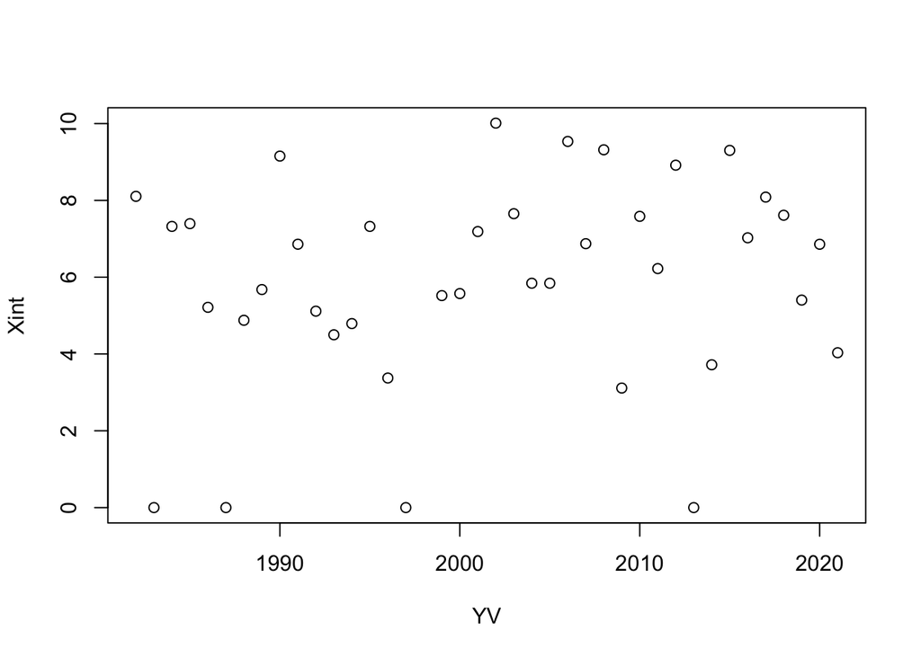

```r
plot(YV,Xint)
```

```r
ciint=t.test(Xint, na.rm=TRUE)
print(paste("mean ann MHW intensity =", format(ciint$estimate,digits=3),"+/-",format(ciint$conf.int[2]-ciint$estimate,digits=3)))
```

```
## [1] "mean ann MHW intensity = 5.92 +/- 0.866"
```

```r
fitint = lm(Xint ~ YV)
pint = summary(fitint)$coefficients[2,4]
if (pint<0.05) abline(fitint)
print(paste("ann MHW int trend =",format(fitint$coefficients[2],  digits=3),"+/-",format(confint(fitint)[2,2]-fitint$coefficients[2], digits=3)))
```

```
## [1] "ann MHW int trend = 0.0413 +/- 0.0739"
```

```r
print(paste("p = ", format(pint,digits=3)))
```

```
## [1] "p =  0.265"
```

Print and plot MHW exposure mean and trend

```r
plot(YV,Xexp)
ciexp=t.test(Xexp, na.rm=TRUE)
print(paste("mean ann MHW exposure =", format(ciexp$estimate,digits=3),"+/-",format(ciexp$conf.int[2]-ciexp$estimate,digits=3)))
```

```
## [1] "mean ann MHW exposure = 17.2 +/- 3.73"
```

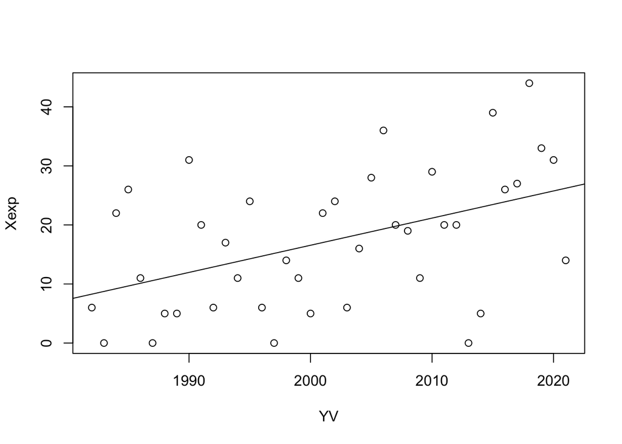

```r
fitexp = lm(Xexp ~ YV)
pexp = summary(fitexp)$coefficients[2,4]
if (pexp<0.05) abline(fitexp)
```

```r
print(paste("ann MHW exp trend =",format(fitexp$coefficients[2],  digits=3),"+/-",format(confint(fitexp)[2,2]-fitexp$coefficients[2], digits=3)))
```

```
## [1] "ann MHW exp trend = 0.46 +/- 0.291"
```

```r
print(paste("p = ", format(pexp,digits=3)))
```

```
## [1] "p =  0.00277"
```

Print and plot SST >=28C mean and trend

```r
plot(YV,Xa28)
cia28=t.test(Xa28, na.rm=TRUE)
print(paste("mean days >= 28C =", format(cia28$estimate,digits=3),"+/-",format(cia28$conf.int[2]-cia28$estimate,digits=3)))
```

```
## [1] "mean days >= 28C = 31.8 +/- 3.76"
```

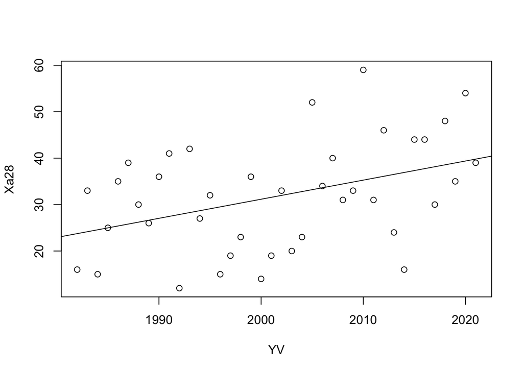

```r
fita28 = lm(Xa28 ~ YV)
pa28 = summary(fita28)$coefficients[2,4]
if (pa28<0.05) abline(fita28)
```

```r
print(paste("SST >= 28C trend =",format(fita28$coefficients[2],  digits=3),"+/-",format(confint(fita28)[2,2]-fita28$coefficients[2], digits=3)))
```

```
## [1] "SST >= 28C trend = 0.412 +/- 0.301"
```

```r
print(paste("p = ", format(pa28,digits=3)))
```

```
## [1] "p =  0.00876"
```

Print and plot MHW duration mean and trend

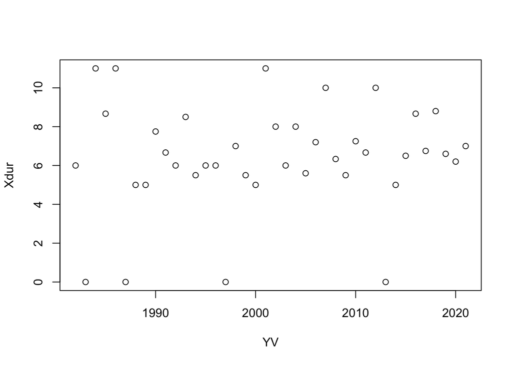

```r
plot(YV,Xdur)
```

```r
cidur=t.test(Xdur, na.rm=TRUE)
print(paste("mean ann MHW duration =", format(cidur$estimate,digits=3),"+/-",format(cidur$conf.int[2]-cidur$estimate,digits=3)))
```

```
## [1] "mean ann MHW duration = 6.44 +/- 0.879"
```

```r
fitdur = lm(Xdur ~ YV)
pdur = summary(fitdur)$coefficients[2,4]
if (pdur<0.05) abline(fitdur)
print(paste("MHW duration trend =", format(fitdur$coefficients[2],  digits=3),"+/-",format(confint(fitdur)[2,2]-fitdur$coefficients[2], digits=3)))
```

```
## [1] "MHW duration trend = 0.0261 +/- 0.0767"
```

```r
print(paste("p = ", format(pdur,digits=3)))
```

```
## [1] "p =  0.496"
```

Print and plot MHW number mean and trend

```r
plot(YV,Xmhw)
cimhw=t.test(Xmhw, na.rm=TRUE)
print(paste("mean ann # MHWs =", format(cimhw$estimate,digits=3),"+/-",format(cimhw$conf.int[2]-cimhw$estimate,digits=3)))
```

```
## [1] "mean ann # MHWs = 2.4 +/- 0.516"
```

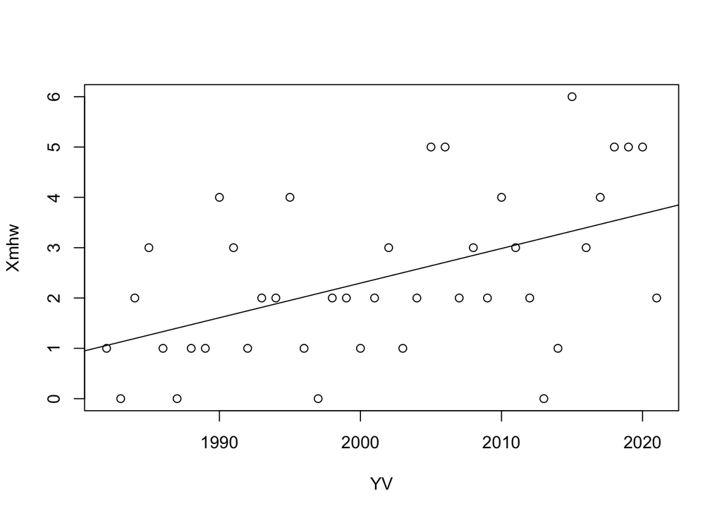

```r
fitmhw = lm(Xmhw ~ YV)
pmhw = summary(fitmhw)$coefficients[2,4]
if (pmhw<0.05) abline(fitmhw)
```

```r
print(paste("Ann # MHWs trend =",format(fitmhw$coefficients[2],  digits=3),"+/-",format(confint(fitmhw)[2,2]-fitmhw$coefficients[2], digits=3)))
```

```
## [1] "Ann # MHWs trend = 0.0689 +/- 0.0393"
```

```r
print(paste("p = ", format(pmhw,digits=3)))
```

```
## [1] "p =  0.00105"
```

Save values for plotting

```r
M = rbind(Xexp,Xint,Xdur,Xa28,Xmhw)
#write.csv(M,"MHWCV.csv")
```

Calculate parameters for autoregressive model ala Oliver 2019

```r
fitL=lm(YHdf$tdT[2:NR]~YHdf$tdT[1:(NR-1)])
slope=as.numeric(fitL$coefficients[2])
sig_e=sd(fitL$residuals)
tau=-1/log(slope)

print(c(slope,sig_e,tau))
```

```
## [1] 0.8818257 1.1610160 7.9515966
```

Calculate 500 instances of SST time series using autoregressive model with parameters slope and se from above.

```r
NS=500  #number of simulations
NR=length(Ddf$Y)
YV=unique(Ddf$Y)
NY=length(YV)
Q=matrix(0,nrow=NR,ncol=NS)

for (j in 1:NS){
  Er = rnorm(NR,mean=0,sd=sig_e)
  for (i in 2:NR) {Q[i,j] = slope*Q[i-1,j] + Er[i]}
}
```

Add trend and seasonal cycle back into time series.

```r
Qt=Q+trend  #add trend from SST data
Qst=Qt+XsV   #add seasonal cycle to trend
Qs=Q+XsV  #add seasonal cycle w/o trend
XY=Ddf$Y
```

```r
vQ=apply(Q,2,var)
summary(vQ)
```

```
##    Min. 1st Qu.  Median    Mean 3rd Qu.    Max.
##   5.437   5.924   6.057   6.059   6.188   6.803
```

```r
var(SSTAnom,na.rm=TRUE)
```

```
## [1] 6.133732
```

Calculate exposure and intensity for simulated SST with trend included.

```r
Qexp=matrix(0,nrow=NY,ncol=NS); Qa28=Qexp; Qint=Qexp; Qdur=Qexp; Qmhw=Qexp
frachi = rep(0,NS); cnt = matrix(0, nrow=NS, ncol=50)
for (j in 1:NS) {
  Xhi=rep(0,NR); N28=Xhi
  Xhi[(Qst[,j]-XthV)>0]=1
  S1=rle(Xhi)$lengths; T1=rle(Xhi)$values
  U1=S1*T1;  E1=U1[-(which(U1==0))]
  evtab = table(factor(E1, levels=1:50))
  cnt[j,]=evtab
  frachi[j]=sum(Xhi)/NR
  dX=diff(Xhi)
  nd = which(dX==1)
  np = which(dX==-1)
  if (np[1]<nd[1]) np=np[-1]
  if (length(np) != length(nd)) nd=nd[-length(nd)]
  durXHi=np-nd
  n5=which(durXHi>=5)
  inten=rep(0,length(n5))
  for (k in 1:length(n5)){
    inten[k]=max(Qt[nd[n5[k]]:np[n5[k]],j])
  }
  Dint=aggregate(inten ~ XY[nd[n5]], FUN=max, na.action=na.pass)
  colnames(Dint)=c("Y","intMHW")
  Sint=rep(0,NY)
  Sint[Dint$Y-YV[1]+1]=Dint$intMHW
  Qint[,j]=Sint

  Dexp=aggregate(durXHi[n5] ~ XY[nd[n5]], FUN=sum, na.action=na.pass)
  colnames(Dexp)=c("Y","expMHW")
  Sexp=rep(0,NY)
  Sexp[Dexp$Y-YV[1]+1]=Dexp$expMHW
  Qexp[,j]=Sexp

  N28[Qst[,j]>=28]=1
  a28=aggregate(N28 ~ XY, FUN=sum, na.action=na.pass)
  colnames(a28)=c("Y","abv28")
  Sa28=rep(0,NY)
  Sa28[a28$Y-YV[1]+1]=a28$abv28
  Qa28[,j]=Sa28

  Ddur=aggregate(durXHi[n5] ~ XY[nd[n5]], FUN=mean, na.action=na.pass)
  colnames(Ddur)=c("Y","durMHW")
  Sdur=rep(0,NY)
  Sdur[Ddur$Y-YV[1]+1]=Ddur$durMHW
  Qdur[,j]=Sdur

  Dmhw=aggregate(nd[n5] ~ XY[nd[n5]], FUN=NROW, na.action=na.pass)
  colnames(Dmhw)=c("Y","nMHW")
  Smhw=rep(0,NY)
  Smhw[Dmhw$Y-YV[1]+1]=Dmhw$nMHW
  Qmhw[,j]=Smhw
}
```

Plot simulation results

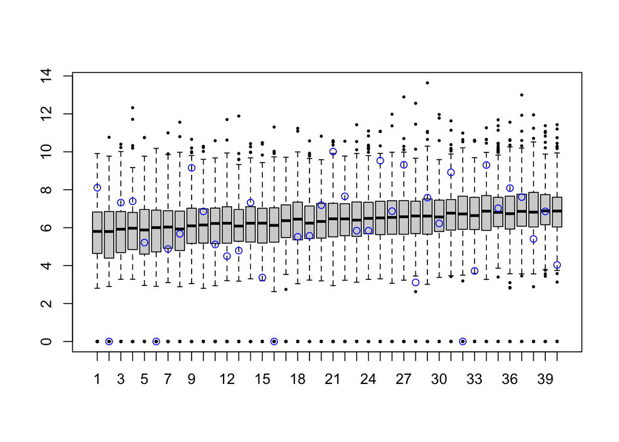

```r
boxplot(t(Qint),outpch=20, outcex=0.5)
points(Xint,col="blue")  #intensity
```

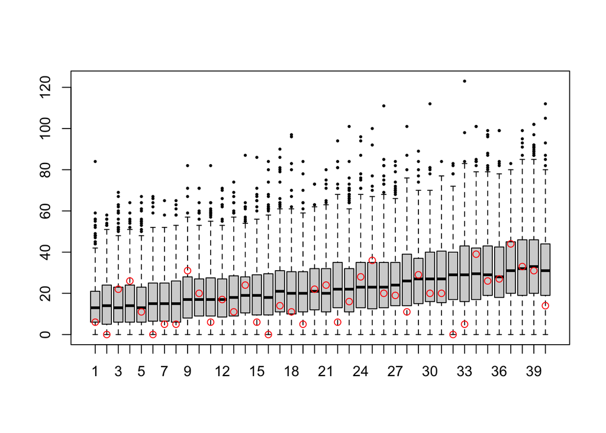

```r
boxplot(t(Qexp),outpch=20, outcex=0.5)
points(Xexp,col="red")  #exposure
```

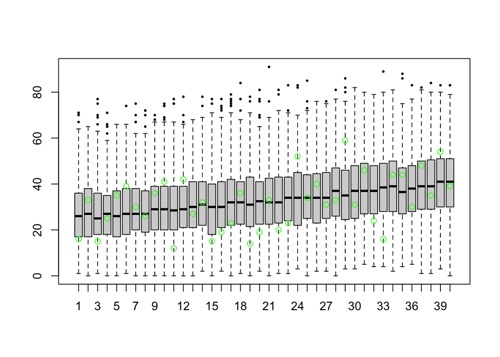

```r
boxplot(t(Qa28),outpch=20, outcex=0.5)
points(Xa28,col="green")  #SST >=28C
```

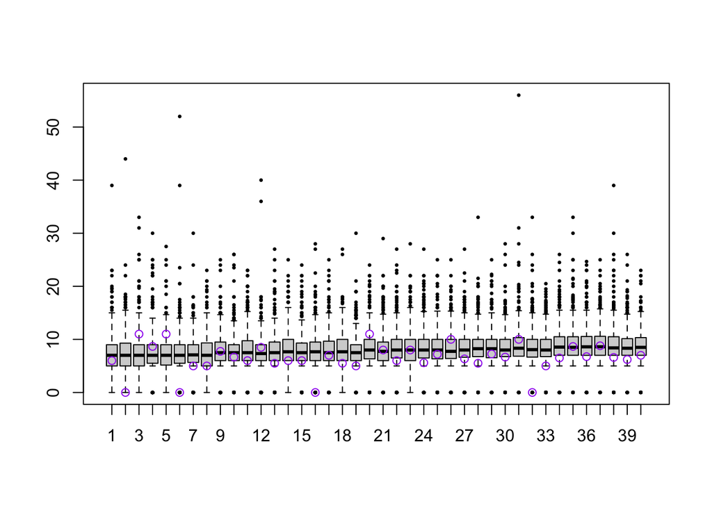

```r
boxplot(t(Qdur),outpch=20, outcex=0.5)
points(Xdur,col="purple")  #duration
```

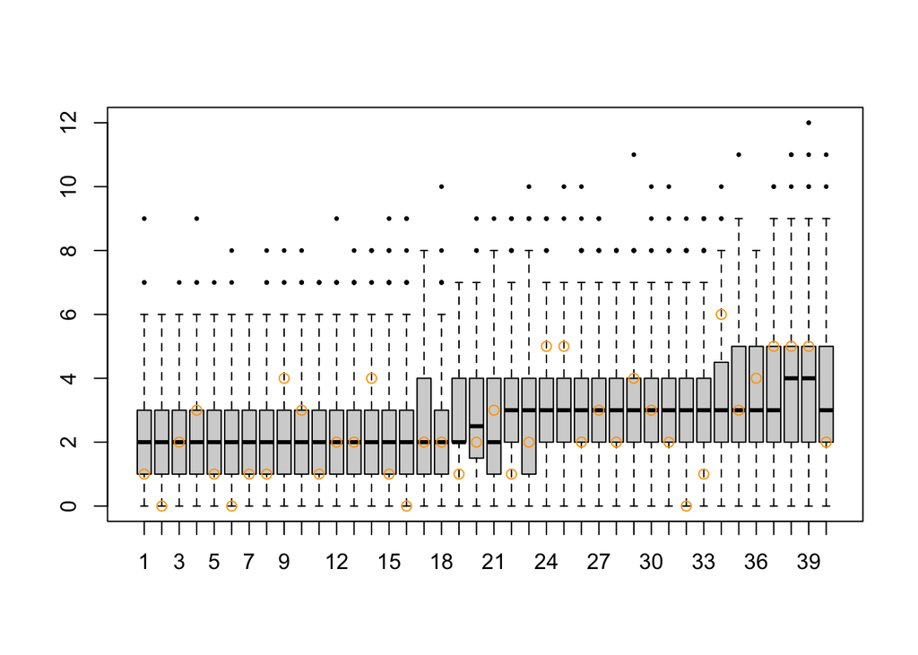

```r
boxplot(t(Qmhw),outpch=20, outcex=0.5)
points(Xmhw,col="orange")  #number of MHWs
```

Calculate and plot exceedance events and durations

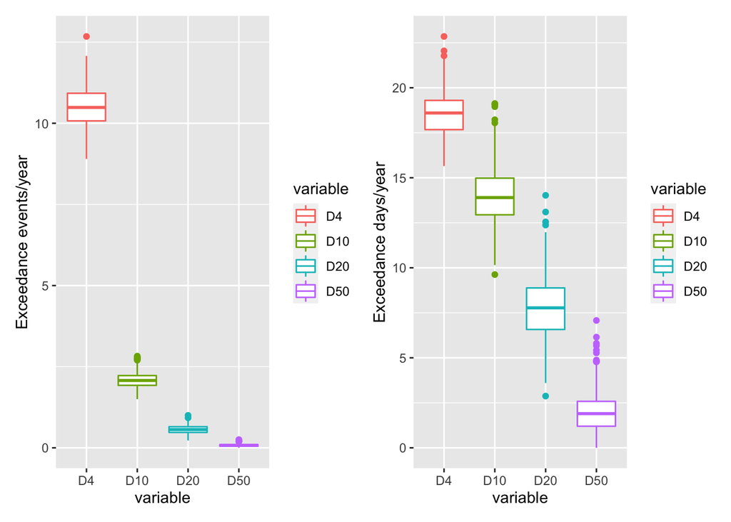

```r
library(reshape2)
library(ggplot2)
library(patchwork)
mcnt = matrix(0, nrow=500, ncol=4); lcnt=mcnt
dcnt=cnt*matrix(rep(1:50,500), byrow=TRUE, nrow=500)
for (i in 1:500) {
  n4=sum(cnt[i,1:4])
  n10=sum(cnt[i,5:10])
  n20=sum(cnt[i,11:20])
  n50=sum(cnt[i,21:50])
  mcnt[i,]=c(n4,n10,n20,n50)
  d4=sum(dcnt[i,1:4])
  d10=sum(dcnt[i,5:10])
  d20=sum(dcnt[i,11:20])
  d50=sum(dcnt[i,21:50])
  lcnt[i,]=c(d4,d10,d20,d50)
}
cdf=data.frame(mcnt/NY)
colnames(cdf)=c("D4","D10","D20","D50")
cmdf=melt(cdf, id=NULL)
ddf=data.frame(lcnt/NY)
colnames(ddf)=c("D4","D10","D20","D50")
dmdf=melt(ddf, id=NULL)
g1=ggplot(data=cmdf, aes(x=variable, y=value, color=variable)) +
  geom_boxplot() +
  ylab("Exceedance events/year")
g2=ggplot(data=dmdf, aes(x=variable, y=value, color=variable)) +
  geom_boxplot() +
  ylab("Exceedance days/year")
print(g1+g2)
```

```r
#write.csv(cbind(cdf,ddf),"EvCntCV.csv")
```

**Extend simulations to 2100**

```r
NS=500  #number of simulations
NY=120 #number of years
NR=NY*365 #record length in days
Z=matrix(0,nrow=NR,ncol=NS)
decY=0:(NY*365)/365+1982; decY=decY[-(length(decY))]
YMD=date_decimal(decY); YMD=as.Date(YMD); M=month(YMD);
ZY=year(YMD)
YV=unique(ZY)

for (j in 1:NS){
  Er = rnorm(NR,mean=0,sd=sig_e)
  for (i in 2:NR) {Z[i,j] = slope*Z[i-1,j] + Er[i]}
}

Ztrend=fitmS$coefficients[1]+fitmS$coefficients[2]*decY
ZsV=rep(Xseas,NY)
Zt=Z+Ztrend  #add trend from SST data
Zst=Zt+ZsV   #add seasonal cycle to trend
ZthV=rep(Xthresh,NY)
```

Calculate MHWs

```r
Zexp=matrix(0,nrow=NY,ncol=NS); Za28=Zexp; Zint=Zexp; Zdur=Zexp; Zmhw=Zexp
frachi = rep(0,NS)
for (j in 1:NS) {
  Xhi=rep(0,NR); N28=Xhi
  Xhi[(Zst[,j]-ZthV)>0]=1
  frachi[j]=sum(Xhi)/NR
  dX=diff(Xhi)
  nd = which(dX==1)
  np = which(dX==-1)
  if (np[1]<nd[1]) np=np[-1]
  if (length(np) != length(nd)) nd=nd[-length(nd)]
  durXHi=np-nd
  n5=which(durXHi>=5)
  inten=rep(0,length(n5))
  for (k in 1:length(n5)){
    inten[k]=max(Zt[nd[n5[k]]:np[n5[k]],j])
  }
  Dint=aggregate(inten ~ ZY[nd[n5]], FUN=max, na.action=na.pass)
  colnames(Dint)=c("Y","intMHW")
  Sint=rep(0,NY)
  Sint[Dint$Y-YV[1]+1]=Dint$intMHW
  Zint[,j]=Sint

  Dexp=aggregate(durXHi[n5] ~ ZY[nd[n5]], FUN=sum, na.action=na.pass)
  colnames(Dexp)=c("Y","expMHW")
  Sexp=rep(0,NY)
  Sexp[Dexp$Y-YV[1]+1]=Dexp$expMHW
  Zexp[,j]=Sexp

  N28[Zst[,j]>=28]=1
  a28=aggregate(N28 ~ ZY, FUN=sum, na.action=na.pass)
  colnames(a28)=c("Y","abv28")
  Sa28=rep(0,NY)
  Sa28[a28$Y-YV[1]+1]=a28$abv28
  Za28[,j]=Sa28

  Ddur=aggregate(durXHi[n5] ~ ZY[nd[n5]], FUN=mean, na.action=na.pass)
  colnames(Ddur)=c("Y","durMHW")
  Sdur=rep(0,NY)
  Sdur[Ddur$Y-YV[1]+1]=Ddur$durMHW
  Zdur[,j]=Sdur

  Dmhw=aggregate(nd[n5] ~ ZY[nd[n5]], FUN=NROW, na.action=na.pass)
  colnames(Dmhw)=c("Y","nMHW")
  Smhw=rep(0,NY)
  Smhw[Dmhw$Y-YV[1]+1]=Dmhw$nMHW
  Zmhw[,j]=Smhw
}
```

Plot simulation results

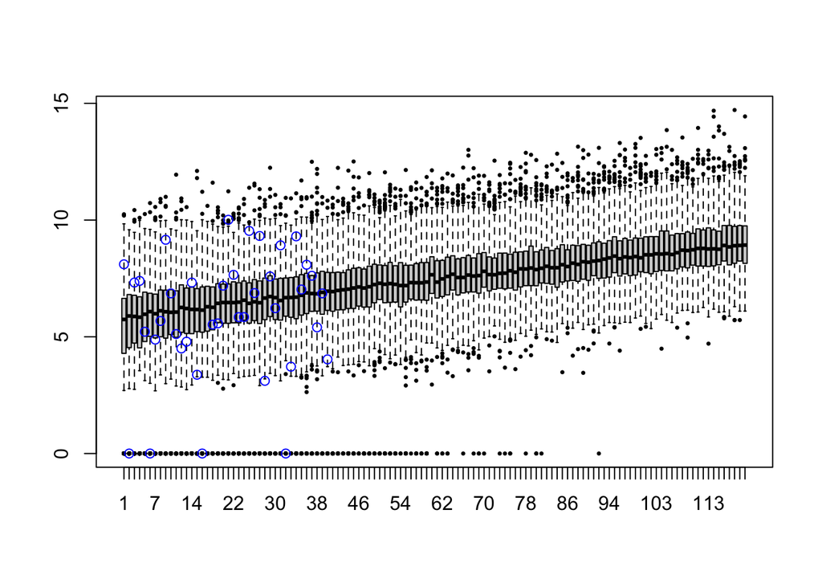

```r
boxplot(t(Zint),outpch=20, outcex=0.5)
points(Xint,col="blue")  #intensity
```

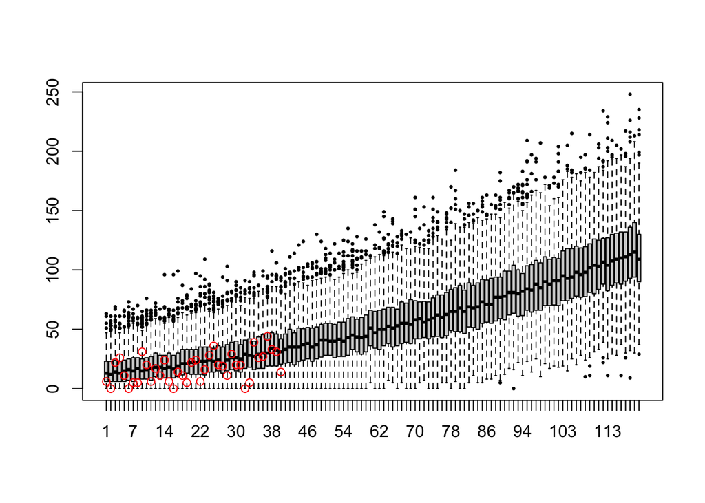

```r
boxplot(t(Zexp),outpch=20, outcex=0.5)
points(Xexp,col="red")  #exposure
```

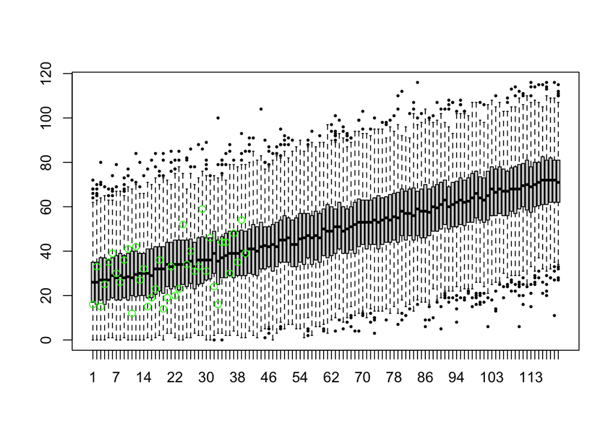

```r
boxplot(t(Za28),outpch=20, outcex=0.5)
points(Xa28,col="green")  #SST >= 28C
```

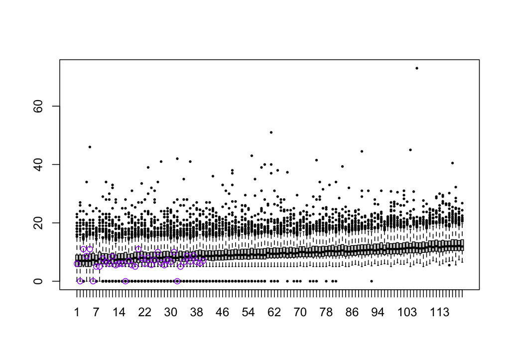

```r
boxplot(t(Zdur),outpch=20, outcex=0.5)
points(Xdur,col="purple")  #duration
```

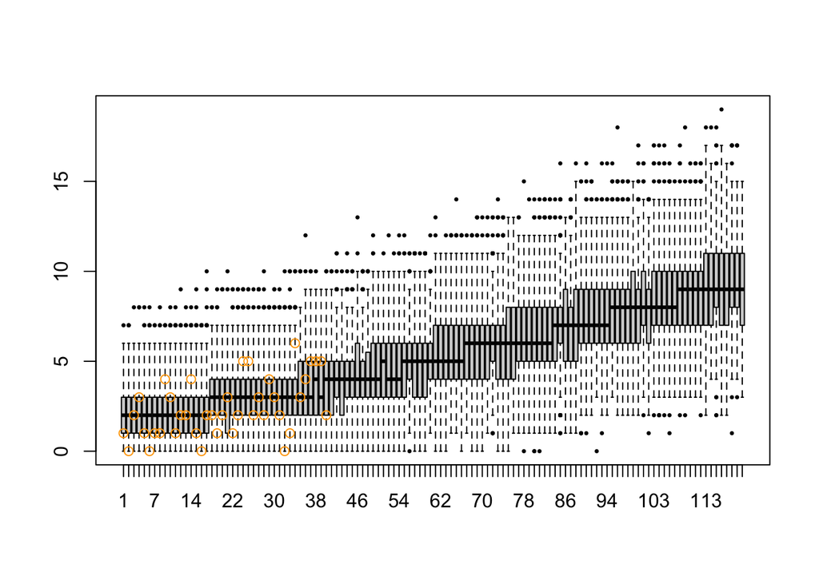

```r
boxplot(t(Zmhw),outpch=20, outcex=0.5)
points(Xmhw,col="orange")  #number MHWs
```

Calculate and print trends on MHW simulation stats

```r
#intensity
DIM=t.test(Zint[120,], na.rm=TRUE)
print(paste("sim mean MHW intensity 2100 =", format(DIM$estimate,digits=3),"+/-",format(DIM$conf.int[2]-DIM$estimate,digits=1)))
```

```
## [1] "sim mean MHW intensity 2100 = 9.01 +/- 0.1"
```

```r
simfitint = lm(rowMeans(Zint) ~ YV)
spint = summary(simfitint)$coefficients[2,4]
print(paste("sim MHW int trend =",format(simfitint$coefficients[2],  digits=3),"+/-",format(confint(simfitint)[2,2]-simfitint$coefficients[2], digits=3)))
```

```
## [1] "sim MHW int trend = 0.0314 +/- 0.000794"
```

```r
print(paste("p = ", format(spint,digits=3)))
```

```
## [1] "p =  1.3e-103"
```

```r
#exposure
DEM=t.test(Zexp[120,], na.rm=TRUE)
print(paste("sim mean MHW exposure 2100 =", format(DEM$estimate,digits=3),"+/-",format(DEM$conf.int[2]-DEM$estimate,digits=1)))
```

```
## [1] "sim mean MHW exposure 2100 = 111 +/- 3"
```

```r
simfitexp = lm(rowMeans(Zexp) ~ YV)
spexp = summary(simfitexp)$coefficients[2,4]
print(paste("sim ann MHW exp trend =",format(simfitexp$coefficients[2],  digits=3),"+/-",format(confint(simfitexp)[2,2]-simfitexp$coefficients[2], digits=3)))
```

```
## [1] "sim ann MHW exp trend = 0.849 +/- 0.0271"
```

```r
print(paste("p = ", format(spexp,digits=3)))
```

```
## [1] "p =  5.64e-92"
```

```r
#SST >= 28C
DAM=t.test(Za28[120,], na.rm=TRUE)
print(paste("sim mean SST>=28C 2100 =", format(DAM$estimate,digits=3),"+/-",format(DAM$conf.int[2]-DAM$estimate,digits=1)))
```

```
## [1] "sim mean SST>=28C 2100 = 71.3 +/- 1"
```

```r
simfita28 = lm(rowMeans(Za28) ~ YV)
spa28 = summary(simfita28)$coefficients[2,4]
print(paste("sim SST >= 28C trend =",format(simfita28$coefficients[2],  digits=3),"+/-",format(confint(simfita28)[2,2]-simfita28$coefficients[2], digits=3)))
```

```
## [1] "sim SST >= 28C trend = 0.388 +/- 0.00438"
```

```r
print(paste("p = ", format(spa28,digits=3)))
```

```
## [1] "p =  1.56e-144"
```

```r
#duration
DDM=t.test(Zdur[120,], na.rm=TRUE)
print(paste("sim mean MHW duration 2100 =", format(DDM$estimate,digits=3),"+/-",format(DDM$conf.int[2]-DDM$estimate,digits=1)))
```

```
## [1] "sim mean MHW duration 2100 = 12.5 +/- 0.3"
```

```r
simfitdur = lm(rowMeans(Zdur) ~ YV)
spdur = summary(simfitdur)$coefficients[2,4]
print(paste("sim MHW duration =", format(simfitdur$coefficients[2],  digits=3),"+/-",format(confint(simfitdur)[2,2]-simfitdur$coefficients[2], digits=3)))
```

```
## [1] "sim MHW duration = 0.0448 +/- 0.000933"
```

```r
print(paste("p = ", format(spdur,digits=3)))
```

```
## [1] "p =  2.03e-113"
```

```r
#number MHWs
DHM=t.test(Zmhw[120,], na.rm=TRUE)
print(paste("sim mean number MHWs 2100 =", format(DHM$estimate,digits=3),"+/-",format(DHM$conf.int[2]-DHM$estimate,digits=1)))
```

```
## [1] "sim mean number MHWs 2100 = 9.07 +/- 0.2"
```

```r
simfitmhw = lm(rowMeans(Zmhw) ~ YV)
spmhw = summary(simfitmhw)$coefficients[2,4]
print(paste("Sim Ann # MHWs =",format(simfitmhw$coefficients[2],  digits=3),"+/-",format(confint(simfitmhw)[2,2]-simfitmhw$coefficients[2], digits=3)))
```

```
## [1] "Sim Ann # MHWs = 0.0657 +/- 0.00107"
```

```r
print(paste("p = ", format(spmhw,digits=3)))
```

```
## [1] "p =  1.37e-125"
```